# Gapminder Data

## Gapminder Data Summary

## Data Description

The gapminder data contains information recorded for a number of countries

Variables recorded include: **Country**, **Continent**, **Year**, **Life Expectancy**, **Population**, **GDP Per Capita**

This is another slide added, without a title :)

I wanted to make sure I was able to add a slide, without giving it a title

## Some Univariate Summaries

## Univariate Summaries

It is of interest to take a look at each of the variables, and provide a quick summary, both numerically as well as graphically

## A Quick Glance

Following are basic univariate summaries for each variable:

```
##         country        continent        year         lifeExp
##  Afghanistan:  12   Africa  :624   Min.   :1952   Min.   :23.60
##  Albania    :  12   Americas:300   1st Qu.:1966   1st Qu.:48.20
##  Algeria    :  12   Asia    :396   Median :1980   Median :60.71
##  Angola     :  12   Europe  :360   Mean   :1980   Mean   :59.47
##  Argentina  :  12   Oceania : 24   3rd Qu.:1993   3rd Qu.:70.85
##  Australia  :  12                  Max.   :2007   Max.   :82.60
##  (Other)    :1632
##       pop              gdpPercap
##  Min.   :6.001e+04   Min.   :   241.2
##  1st Qu.:2.794e+06   1st Qu.:  1202.1
##  Median :7.024e+06   Median :  3531.8
##  Mean   :2.960e+07   Mean   :  7215.3
##  3rd Qu.:1.959e+07   3rd Qu.:  9325.5
##  Max.   :1.319e+09   Max.   :113523.1
##
```

## Countires and Continents

Which countries are represented in the data?

- In total there are 142 countries represented. They are not all listed here for the sake of space.
- There are a total of 5 geopolitical continents recorded:
  - Africa
  - Asia
  - Europe
  - Americas (North America and South America combined)
  - Oceania (Australia, New Zealand, and surrounding island nations)
  - Antarctica is not included in the data

## Years Recorded

The data was collected for a number of years. The years the data was collected for were:

```
##  [1] "1952" "1957" "1962" "1967" "1972" "1977" "1982" "1987" "1992" "1997"
## [11] "2002" "2007"
```

* Just adding some smaller font here for myself…

## Life Expectancy

- Making a figure smaller (should probably center it too)

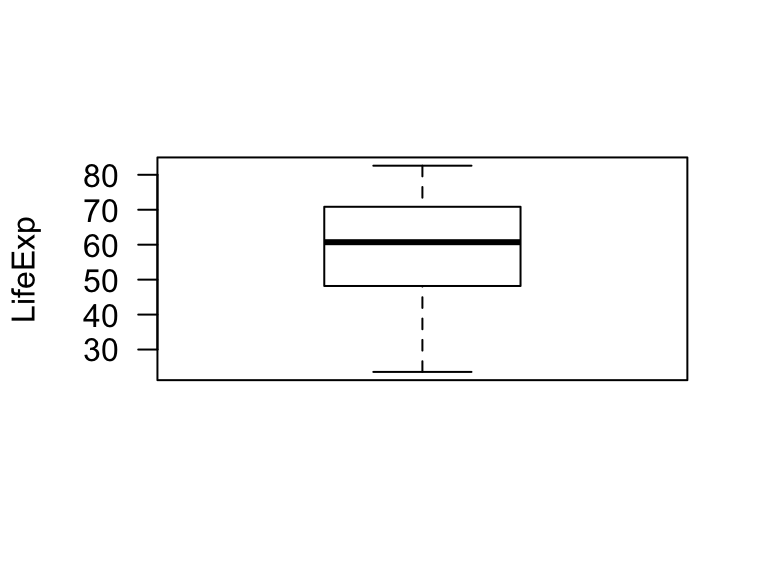

```
##    Min. 1st Qu.  Median    Mean 3rd Qu.    Max.
##   23.60   48.20   60.71   59.47   70.85   82.60
```

## GDP Per Capita

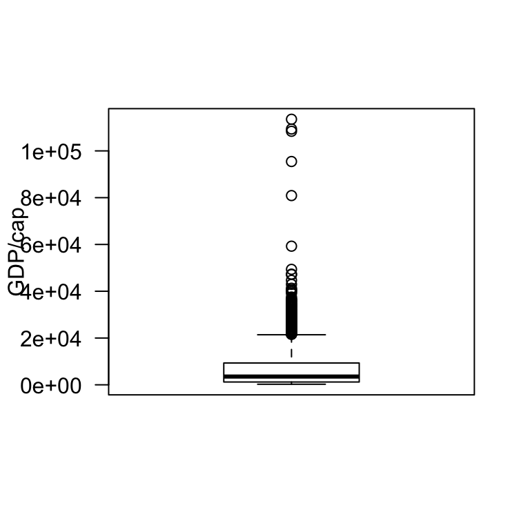

```
##     Min.  1st Qu.   Median     Mean  3rd Qu.     Max.
##    241.2   1202.1   3531.8   7215.3   9325.5 113523.1
```

## log-GDP (because it's a Rate)

A quick note that since GDP/cap is a **rate**, it may be better to be exploring it on the log(ln)-scale

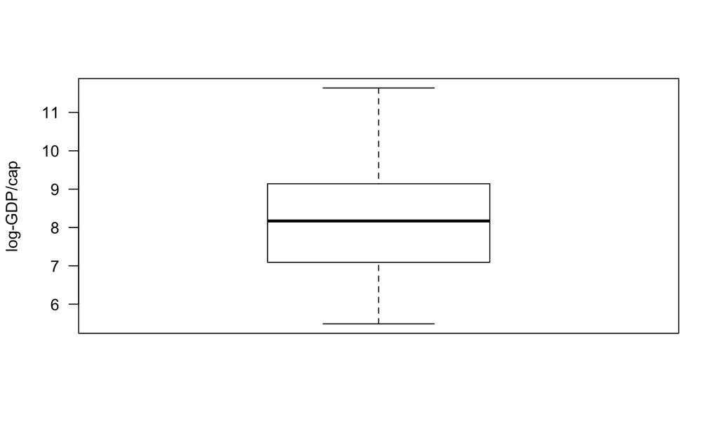

## Population

Here are words…

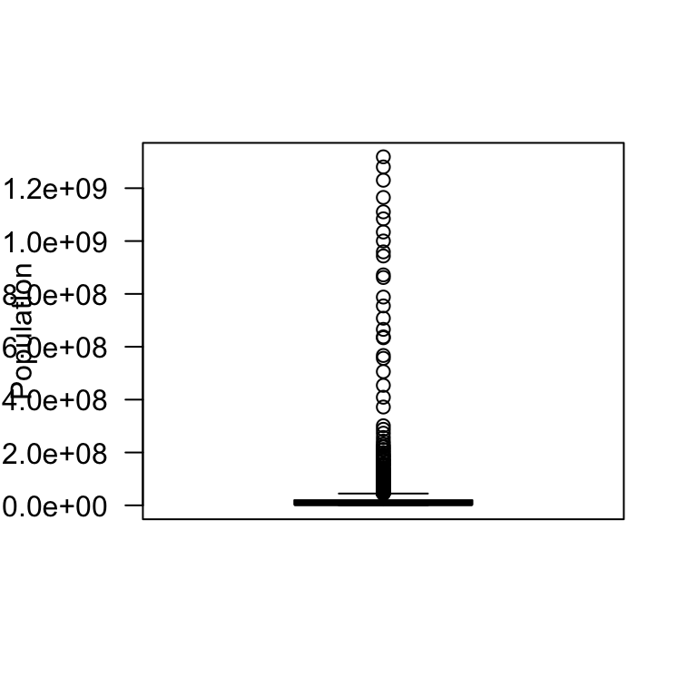

## log-Population

Again, it may be better to examine this on the log-scale, as populations tend to grow exponentially

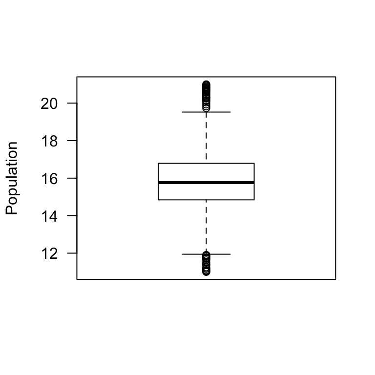

## Some Bivariate Summaries

## Bivariate Summaries

We may be interested in examining relationships between some of the variables. Following are a few of interest.

Note, we are ignoring the fact that the same countires have measurements taken for multiple years, for the time being…

## Life Expectancy and GDP

It is reasonable to hypothesize that these would be related. Following is a visual examination of their relationship

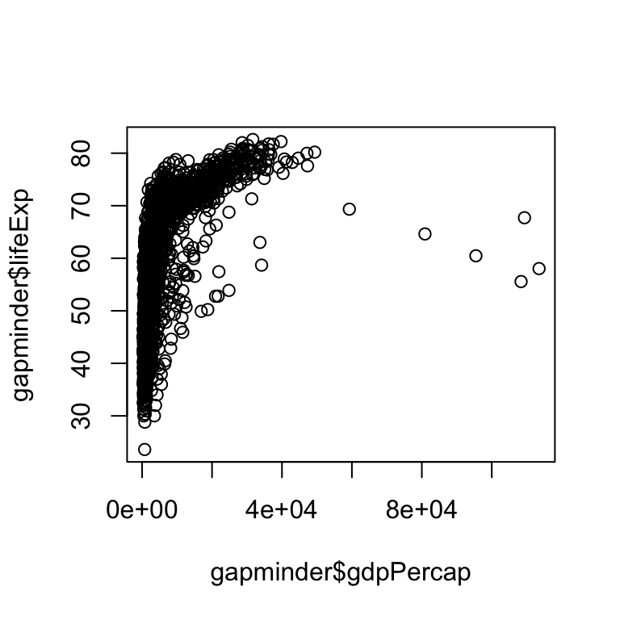

## Pearson's correlation

While the relationship clearly isn't linear, let's calculate this anyway…

```r
cor(gapminder$gdpPercap, gapminder$lifeExp)
```

```
## [1] 0.5837062
```

## Spearman's Correlation

Let's calculate Spearman's correlation to address the non-linearity, as it does appear to be a monotonic association:

```r
cor(gapminder$gdpPercap, gapminder$lifeExp, method="spearman")
```

```
## [1] 0.8264712
```

This makes more sense, but still, we can try other things…

## Using log-GDP

Let's look at the same plot, but this time using the log-GDP-per-capita, as it makes sense to examine it on this scale

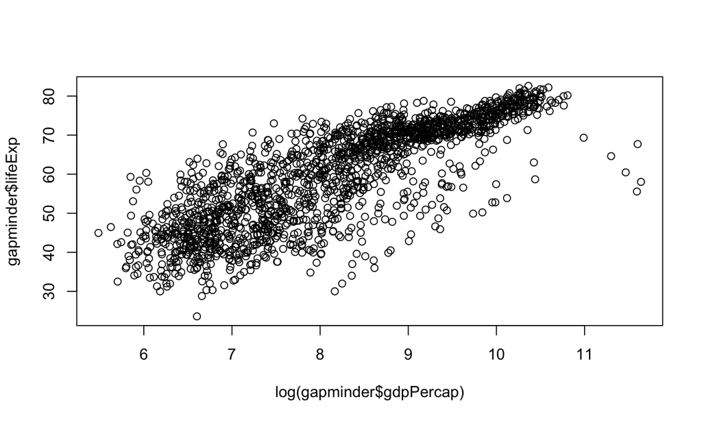

## That Looked Like a Fix!

That looks like it would be easier to model. Let's also take a quick look at Pearson's correlation when we use log-GDP…

```r
cor(log(gapminder$gdpPercap), gapminder$lifeExp, method="pearson")
```

```
## [1] 0.8076179
```

## The End?

## Yes, The End!

This will be the ending here

- There wasn't much focus on the content of presentation
- I wasn't consistent with using "echo=F" or not
  - But that's because I wanted to focus on learning more about how it formats slides, etc
- Some basic things were tried
- I don't really care about my grade, I just want to learn about the course material